# Classification with a linear neural network

## Task 1. Prepare data for training and model selection

### 1.1 Load the data and visualize an image for each class

```python
import numpy as np

images = np.load('data/imgs_train.npy')
labels = np.load('data/labels_train.npy')

test_images = np.load('data/imgs_test.npy')
test_labels = np.load('data/labels_test.npy')
```

```python
def find_each_class(labels):
    # Creates a list in which the first occurence of each class is stored.
    indexes_for_each_label = list()

    for label in range(10):
        index = np.where(labels==label)[0][0]
        indexes_for_each_label.append(index) # Add index where the corresponding label was found to list

    # Index in this list: Class. Value in this list: First occurrence in np array 'labels'.
    return indexes_for_each_label
```

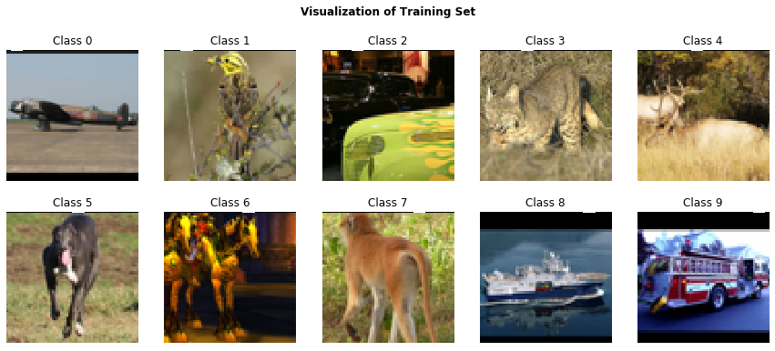

```python
%matplotlib inline
import matplotlib.pyplot as plt

def print_dataset(images, labels, columns, rows, dataset_name):
    # Creates one large figure (to put the smaller in it)
    fig=plt.figure(figsize=(columns*3, 6))
    plt.title('Visualization of ' + str(dataset_name) + '\n\n', fontweight = "bold")
    plt.axis('off')
    imgs = []

    # Iterates through the images and add them as subs to figure
    for i in range(1, columns*rows+1):
        for index in find_each_class(labels):
            img = images[index]
            imgs.append(img)
        fig.add_subplot(rows, columns, i)
        plt.title('Class ' + str(i-1))
        plt.axis('off')
        plt.imshow(imgs[i-1])

    plt.show()

print_dataset(images, labels, 5, 2, 'Training Set')
```

### 1.2 Set aside 90% of training data for training, and the remaining 10% for validation

Make sure the label distribution is the same in training and validation set.

```python
from sklearn.model_selection import train_test_split

images_train, images_val, labels_train, labels_val =\
    train_test_split(images, labels, train_size=0.9, stratify=labels, random_state=42)
```

### 1.3 Implement a Dataset class that extends Pytorch’s Dataset class

```python
import torch

device = torch.device('cuda' if torch.cuda.is_available() else 'cpu')
```

```python
from torchvision.transforms import Resize, ToTensor, Normalize, Compose

class ATMLDatasetWrapper(torch.utils.data.Dataset):
    ''' Wrapper class for given dataset '''
    def __init__(self, dataset, labels):
        self.transforms = Compose([ToTensor(), Normalize(mean=(0.5, 0.5, 0.5,), std=(0.5, 0.5, 0.5)),])
        self.data = [self.transforms(sample) for sample in dataset]
        self.labels = labels # Different to example of Tutorial 3
        self.n = len(dataset)

    def __getitem__(self, ind):
        return self.data[ind], self.labels[ind]

    def __len__(self):
        return self.n
```

Create dataset objects and dataloaders for created datasets. Make sure you normalize your data.

```python
from torch.utils.data import DataLoader

# Datasets
dataset_train = ATMLDatasetWrapper(images_train, labels_train)
dataset_val = ATMLDatasetWrapper(images_val, labels_val)
dataset_test = ATMLDatasetWrapper(test_images, test_labels)

# Dataloaders
batch_size, num_workers = 32, 0
train_dataloader = DataLoader(dataset_train, batch_size = batch_size, shuffle = True, num_workers=num_workers)
val_dataloader = DataLoader(dataset_val, batch_size = batch_size, shuffle = True, num_workers = num_workers)
test_dataloader = DataLoader(dataset_test, batch_size = batch_size, shuffle = True, num_workers = num_workers)
```

## Task 2. Train a linear classification model

Implement a linear classification model that will predict the label of a given image. Implement the training of the model with PyTorch's optimizer and a loss function appropriate for the task.

Training at least 3 models using different (reasonable) learning rates, training for at least 10 epochs. For each model evaluating on validation dataset after every epoch. Plotting training and validation loss and ac- curacy per epoch. Selecting the best model based on the results on the validation set.

```python
import torch.nn as nn
class LinearModel(nn.Module):

    def __init__(self, input_dim):
        super(LinearModel, self).__init__()
        self.fc = nn.Linear(input_dim, 10, bias=True) # 10 since we have 10 classes

    def forward(self, input):
        out = input.view(input.size(0), -1) # To batch_size x (3 * height * width)
        out = self.fc(out) # Applies out = input * A + b where A, b are parameters to learn.
        return out
```

```python
def train_epoch(model, train_dataloader, optimizer, loss_fn):
    # Initialize losses and correct predictions counter
    losses = []
    correct_predictions = 0

    # Iterate mini batches over training dataset
    for images, labels in train_dataloader:
        images = images.to(device)
        labels = labels.to(device)
        output = model(images) # Predictions
        optimizer.zero_grad() # Set gradients to 0
        loss = loss_fn(output, labels) # Compute loss
        loss.backward() # With backpropagation compute gradients
        optimizer.step() # Optimization step -> Update of weights
        losses.append(loss.item())
        predicted_labels = output.argmax(dim=1) # Precicted class
        correct_predictions += (predicted_labels == labels).sum().item() # Update amount of correct predictions (if possible)

    accuracy = 100.0 * correct_predictions / len(train_dataloader.dataset) # Compute accuracy
    mean_loss = np.array(losses).mean() # Compute the mean

    # Return metrics of epoch
    return mean_loss, accuracy
```

```python
def evaluate(model, dataloader, loss_fn):
    # Initialize losses and correct predictions counter
    losses = []
    correct_predictions = 0

    with torch.no_grad():
        for images, labels in dataloader:
            images = images.to(device)
            labels = labels.to(device)
            output = model(images) # Predictions
            loss = loss_fn(output, labels) # Compute loss
            predicted_labels = output.argmax(dim=1) # Predicted class
            correct_predictions += (predicted_labels == labels).sum().item() # Update amount of correct predictions (if possible)
            losses.append(loss.item()) # Add the computed loss to losses

    mean_loss = np.array(losses).mean()
    accuracy = 100.0 * correct_predictions / len(dataloader.dataset)

    return mean_loss, accuracy
```

```python
def train(model, train_dataloader, val_dataloader, optimizer, n_epochs, loss_function):
    # Save metrics as the training progresses
    train_losses, val_losses, train_accuracies, val_accuracies = ([] for i in range(4))

    for epoch in range(n_epochs):
        model.train() # Model goes to train
        train_loss, train_accuracy = train_epoch(model, train_dataloader, optimizer, loss_fn) # Train model for 1 epoch
        model.eval() # Model goes to evaluating
        val_loss, val_accuracy = evaluate(model, val_dataloader, loss_fn) # Computation of metrics

        # Append computed values to corresponding list
        train_losses.append(train_loss)
        val_losses.append(val_loss)
        train_accuracies.append(train_accuracy)
        val_accuracies.append(val_accuracy)
        print('Epoch {}/{}: train_loss: {:.4f}, train_accuracy: {:.4f}, val_loss: {:.4f}, val_accuracy: {:.4f}'.format(epoch+1, n_epochs,
                                                                                                      train_losses[-1],
                                                                                                      train_accuracies[-1],
                                                                                                      val_losses[-1],
                                                                                                      val_accuracies[-1]))
    return train_losses, val_losses, train_accuracies, val_accuracies
```

```python
def sub_plotting(learning_rate, n_epochs, train_metr, val_metr, metric_name):
    plt.figure()
    plt.title('Model\'s ' + str(metric_name) + ' with Learning Rate = ' + str(learning_rate), fontweight='bold')
    plt.plot(list(range(1,n_epochs+1)), train_metr, label='Training')
    plt.plot(list(range(1,n_epochs+1)), val_metr, label='Validation')
    plt.xlabel('Epoch')
    plt.ylabel(str(metric_name))
    plt.legend()
    plt.xticks(np.arange(1, n_epochs+1, 1.0))
```

```
Model is trained with learning rate: 0.1

Model is trained with learning rate: 0.01

Model is trained with learning rate: 0.001

Model is trained with learning rate: 0.0001
```

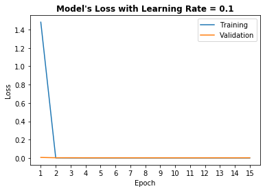

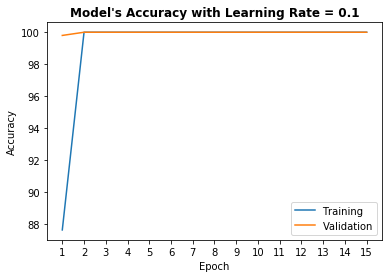

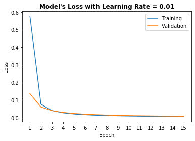

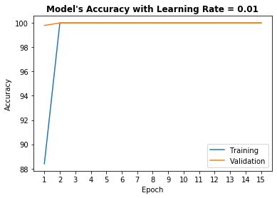

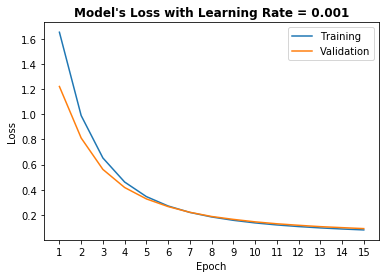

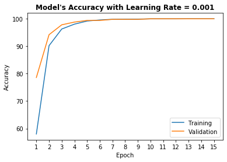

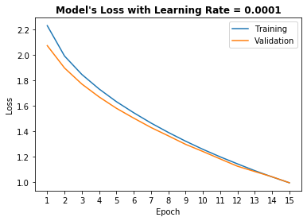

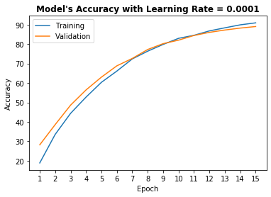

```python
# Initialize loss function, amount of epochs and learning rates
# Optimizer will be initialized depending on learning rate, therefore below in loop
loss_fn = torch.nn.CrossEntropyLoss() # Use PyTorch's CrossEntropyLoss function
n_epochs = 15
learning_rates = [0.1, 0.01, 0.001, 0.0001]

# We examine multiple models
models, losses = ([] for i in range(2))

for i, learning_rate in enumerate(learning_rates):
    model = LinearModel(64*64*3) # 64 pixels
    model = model.to(device)
    models.append(model) # Append the current model to the multiple models we examine

    # Training part with the current learning rate
    print('\nModel is trained with learning rate: ' + str(learning_rate))
    optimizer = torch.optim.SGD(model.parameters(), lr=learning_rate) # Use appropriate optimizer from torch
    train_losses, val_losses, train_acc, val_acc = train(model, train_dataloader, val_dataloader, optimizer, n_epochs, loss_fn)

    # Plotting
    sub_plotting(learning_rate, n_epochs, train_losses, val_losses, 'Loss')
    sub_plotting(learning_rate, n_epochs, train_acc, val_acc, 'Accuracy')

    # Save validation loss of last epoch
    losses.append(val_losses[-1])


# Plotting
plt.show()

# Select best model based on results on validation set (smallest loss, last epoch)
best_model = models[np.argmin(losses)]
```

#### Report below:

**REPORT** *plots, validation losses and accuracies for different learning rates, learning rate for the selected best performing model*

**> Plots:**  
Plots can be seen above in output.

**> Training and validation loss and accuracy for different learning rates on the last epochs were:**  
Learning Rate: **0.1**  
Epoch 15/15: train_loss: 0.0001, train_accuracy: 100.0000, val_loss: 0.0021, val_accuracy: 100.0000  
Learning Rate: **0.01**  
Epoch 15/15: train_loss: 0.0061, train_accuracy: 100.0000, val_loss: 0.0081, val_accuracy: 100.0000  
Learning Rate: **0.001**  
Epoch 15/15: train_loss: 0.0805, train_accuracy: 100.0000, val_loss: 0.0910, val_accuracy: 100.0000  
Learning Rate: **0.0001**  
Epoch 15/15: train_loss: 0.9965, train_accuracy: 90.8889, val_loss: 0.9966, val_accuracy: 89.0000

**> Learning rate for the selected best performing model:**  
Since the best performing model was selected by the smallest loss in validation set on the last epoch, the corresponding learning rate is: **0.1** (with a val_loss of 0.0021)

**> Initial thoughts about this step:**  
Within the first three learning rates the accuracy was both for the training set and the validation set 100%. This is in my opinion suspiciously high. Probably the accuracy on the test set will be lower since there are more samples than in the validation set.

## Task 3. Evaluate on the test set

### 3.1 Evaluate your selected model on the test set

```python
# Use model with smallest loss on validation set now on the test set
test_loss, test_acc = evaluate(best_model, test_dataloader, loss_fn)
print('Loss on Test Set: ' + str(test_loss) + '\tAccuracy on Test Set: ' + str(test_acc))
```

```
Loss on Test Set: 10.073181539535522	Accuracy on Test Set: 10.7625
```

### 3.2 Visualize a few images from your test dataset

[figure not shown]

```python
# Want again (as in Task 1) visualize an image from each class
print_dataset(test_images, test_labels, 5, 2, 'Test Set')
```

### 3.3 Visualize the weights of your linear model

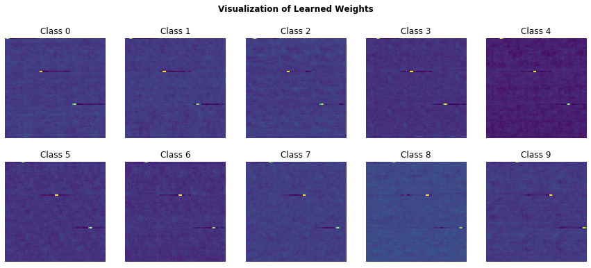

```python
class_weights = []

for i in range(10):
    class_weight = best_model.fc.weight[i].view(64, 64, 3).detach().cpu().numpy()
    class_weight = np.mean(class_weight, axis=2)
    class_weight = (class_weight - class_weight.min()) / class_weight.max() # normalize
    class_weights.append(class_weight)

print_dataset(class_weights, np.arange(10), 5, 2, 'Learned Weights') # np arange since list range doesn't work
```

#### Report below:

**REPORT**: Compare validation and test acccuracy. Comment on differences.  
How are test images different from train images?  
Visualize weights of your best linear model. What did the model learn? How does it distinguish images? Why does it fail on test images?

As suspected the accuracy on the trainning set is lower than before, but it is oddly low with only **10%** (on validation set 100% !!). Therefore one can conclude that the model didn't learn something meaningful to use in classification.

Since on the validation set the accuracy is much better I suppose the underlying problem is somewhat of a different distribution of images in validation and test set. Unfortunately there is no visible proof concerning the "causal content" while printing the images from train and test set.

With visualization of the weights one can see an occuring pattern that is used for the classification: The special pixels are always on the same height/position. Since the question is explicitely "Why does it fail on test images" and because of the visualizations I assume there was some information added explicitely to lead the model to fail. While looking closer on the images one can see that the first row of each image doesn't complete the image in a meaningful way, it is rather one line of black pixels with some white ones in it.

## Task 4. Fix the observed problem

My proposal is to **remove this black line** and retrain the model.

```python
# Make copies
images_train2 = images_train
images_val2 = images_val
test_images2 = test_images

# Remove black line by setting it to 0 (format will be maintained)
images_train2[:, 0, :, :] = np.zeros((64,3))
images_val2[:, 0, :, :] = np.zeros((64,3))
test_images2[:, 0, :, :] = np.zeros((64,3))

# Create datasets and dataloaders again
dataset_train2 = ATMLDatasetWrapper(images_train2, labels_train)
dataset_val2 = ATMLDatasetWrapper(images_val2, labels_val)
dataset_test2 = ATMLDatasetWrapper(test_images2, test_labels)

train_dataloader2 = DataLoader(dataset_train2, batch_size = batch_size, shuffle = True, num_workers=num_workers)
val_dataloader2 = DataLoader(dataset_val2, batch_size = batch_size, shuffle = True, num_workers = num_workers)
test_dataloader2 = DataLoader(dataset_test2, batch_size = batch_size, shuffle = True, num_workers = num_workers)
```

Training the model:

```
Model is trained with learning rate: 0.1

Model is trained with learning rate: 0.01

Model is trained with learning rate: 0.001

Model is trained with learning rate: 0.0001
```

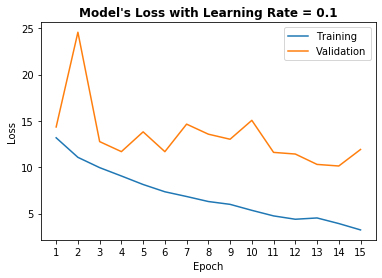

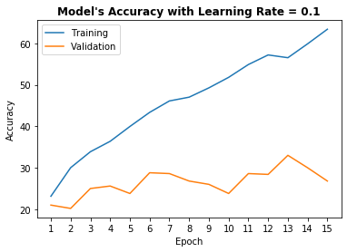

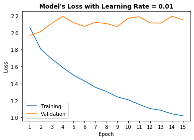

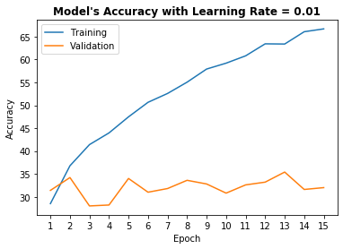

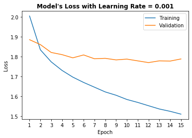

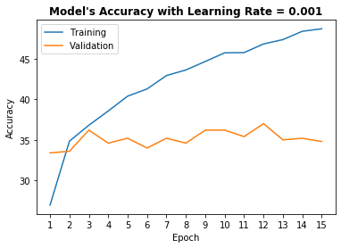

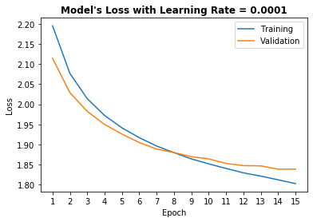

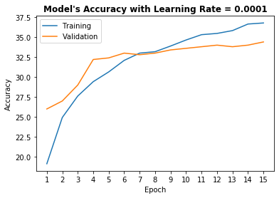

```python
models2, losses2 = ([] for i in range(2))

for i, learning_rate in enumerate(learning_rates):
    model2 = LinearModel(64*64*3) # 64 pixels
    model2 = model2.to(device)
    models2.append(model2) # Append the current model to the multiple models we examine

    # Training part with the current learning rate
    print('\nModel is trained with learning rate: ' + str(learning_rate))
    optimizer = torch.optim.SGD(model2.parameters(), lr=learning_rate) # Use appropriate optimizer from torch
    train_losses2, val_losses2, train_acc2, val_acc2 = train(model2, train_dataloader2, val_dataloader2, optimizer, n_epochs, loss_fn)

    # Plotting
    sub_plotting(learning_rate, n_epochs, train_losses2, val_losses2, 'Loss')
    sub_plotting(learning_rate, n_epochs, train_acc2, val_acc2, 'Accuracy')

    # Save validation loss of last epoch
    losses2.append(val_losses2[-1])


# Plotting
plt.show()

# Select best model based on results on validation set (smallest loss, last epoch)
best_model2 = models2[np.argmin(losses2)]
```

Evaluation on the test set:

```python
test_loss2, test_acc2 = evaluate(best_model2, test_dataloader2, loss_fn)
print('Loss on Test Set: ' + str(test_loss2) + '\tAccuracy on Test Set: ' + str(test_acc2))
```

```
Loss on Test Set: 1.7612357053756713	Accuracy on Test Set: 36.825
```

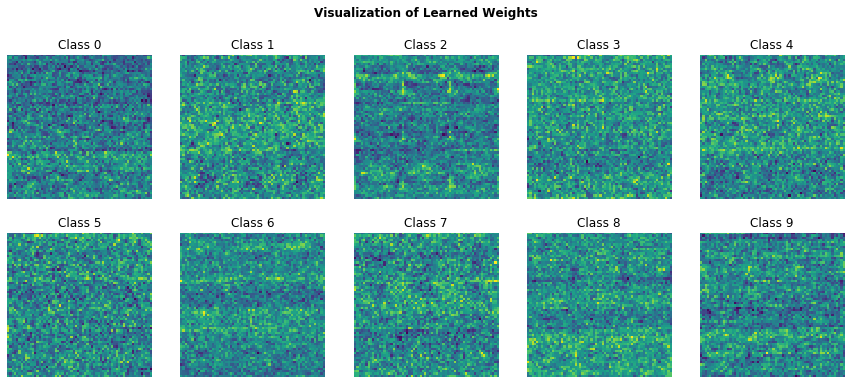

```python
class_weights2 = []

for i in range(10):
    class_weight2 = best_model2.fc.weight[i].view(64, 64, 3).detach().cpu().numpy()
    class_weight2 = np.mean(class_weight2, axis=2)
    class_weight2 = (class_weight2 - class_weight2.min()) / class_weight.max() # normalize
    class_weights2.append(class_weight2)

print_dataset(class_weights2, np.arange(10), 5, 2, 'Learned Weights') # np arange since list range doesn't work
```

#### Report below

Traning and validation loss and accuracy for different learning rates  
Learning rate of the best model  
Test loss and accuracy for the best model  
Compare training, val and test loss and accuracy with the previous model  
Visualize weights of the new model, comment on the differences

**> Training and validation loss and accuracy for different learning rates on the last epochs were:**  
Learning Rate: **0.1**  
Epoch 15/15: train_loss: 3.2356, train_accuracy: 63.4000, val_loss: 11.9129, val_accuracy: 26.8000  
Learning Rate: **0.01**  
Epoch 15/15: train_loss: 1.0210, train_accuracy: 66.6889, val_loss: 2.1523, val_accuracy: 32.0000  
Learning Rate: **0.001**  
Epoch 15/15: train_loss: 1.5111, train_accuracy: 48.6667, val_loss: 1.7889, val_accuracy: 34.8000  
Learning Rate: **0.0001**  
Epoch 15/15: train_loss: 1.8029, train_accuracy: 36.7778, val_loss: 1.8389, val_accuracy: 34.4000

**> Learning rate for the selected best performing model:**  
Since the best performing model was selected by the smallest loss in validation set on the last epoch, the corresponding learning rate is: **0.001** (with a val_loss of 1.7889)

**> Test loss and accuracy for the best model:**  
The loss on the test set is **1.7612** and the accuracy is **36.825**.

**> Comparison of training, val and test loss and accuracy with the previous mode:**  
Previously the values for were:  
Loss = 0.0001, Acc = 100.00 (train), Loss = 0.0021, Acc = 100.00 (val), Loss = 10.0732, Acc = 10.7625 (test)  
Now they are:  
Loss = 1.5111, Acc = 48.6667 (train), Loss = 1.7889 , Acc = 34.8000 (val), Loss = 1.7612, Acc = 36.825 (test)  
One can see that the losses are now bigger in training and validation set but smaller in the test set. Simultaneously, the Accuracy of train and validation set are now lower than in the first model but bigger on the test set with the second approach. The model learns and is more capable in classification. Also, the learning rate value changed for the best performing model.

**> Weights of new model:**  
The visualization of the weights has clearly changed. We see that more meaningful features are being learned and can see some light patterns on the weight visualization (especially visible on Class 2, Class 7 pictures).